# 1. Produce and evaluate multiclass direction predictions for COVID hospitalizations

In this document, we assess our predictions of a simple definition of direction. First we get the data.

```r
# Load the evaluations
save_data <- readRDS(file.path(analysis_dir, paste(analysis_type,"prediction.rds",sep = "-")))
evals <- save_data$evals
evals <- evals %>% rename(target_date = target_end_date)
forecasting_task <- save_data$forecasting_task
forecaster_args <- save_data$forecaster_args

# Load the trained models
forecasters <- unique(evals$forecaster)
trained_models <- lapply(forecasters, FUN = function(forecaster){
  readRDS_from_dir(file.path(model_dir,forecaster))
})
names(trained_models) <- forecasters

# Create coefficient dfs
# coefs <- lapply(trained_models,create_coef_df) %>%
#   bind_rows(.id = "forecaster") %>%
#   mutate(feature_name = parse_feature_name(feature_name))

# Omit whatever was asked to be omitted.
evals <- evals %>% filter(!(forecaster %in% omitted_forecasters) &
                          !(ahead %in% omitted_aheads) &
                          !(forecast_date %in% omitted_forecast_dates))
# coefs <- coefs %>% filter(!(forecaster %in% omitted_forecasters) &
#                       !(ahead %in% omitted_aheads) &
#                       !(forecast_date %in% omitted_forecast_dates))
```

Here’s some information about our forecasting problem: specifically, the forecasting task, the definition of response, the features, and other information on training.

### Forecasting task

Our forecasting task is:

- Geographical resolution: state
- Response variable: hhs, confirmed_admissions_covid_1d
- Incidence period: day
- Forecast date range: 2020-12-01 to 2021-11-01
- Number of days ahead forecast: 14 to 28.

### Response variable

We transform the numeric response into a factor for classification. We will call this variable *direction*. The parameters used to define direction are

- *upswing threshold* (ratio of present minus past value over past value): .1
- *downswing threshold* ratio of present minus past value over past value): -.09
- *minimum threshold* (minimum number of cases needed at past value in order to qualify) 130/14.
- *rollmean* (sliding window over which to take averages): 14.

Let $N_i^{t}(w)$ denote $w$-day trailing average of the response variable, observed at a given {location = i,day = t}. A given {location = i,forecast_date = t,ahead = a} triplet qualifies as an

- increase if

$$\frac{{N}_i^{t + a}(w) - {N}_i^{t}(w)}{{N}_{i}^{t}(w)} \geq u_0~~\textrm{and}~~ {N}_i^{t}(w) \geq t_0$$
where $u_0$ is the upswing threshold, and $t_0$ is the minimum threshold.

- decrease if

$$\frac{{N}_i^{t + a}(w) - {N}_i^{t}(w)}{{N}_{i}^{t}(w)} \leq d_0~~\textrm{and}~~ {N}_i^{t}(w) \geq t_0$$
where $d_0$ is the downswing threshold.

- steady if
  $$d_0 \leq \frac{{N}_i^{t + a}(w) - {N}_i^{t}(w)}{{N}_{i}^{t}(w)} \leq u_0~~\textrm{and}~~ {N}_i^{t}(w) \geq t_0$$
- If $N_i^{t} < t_0$, then the response is coded as NA (i.e. thrown out).

### Features

As features, we use ratios of indicators, evaluated at different lags. The parameters used to define features are:

- *feature_rollmean*: number of days over which to take trailing average: 7
- *feature_lags*: lags at which features are taken: 0, 7, 14
- *ratio_censor*: Truncate any features above this value: 5

To be precise, let $X_i^{t}(w)$ denote $w$-day trailing average of an indicator variable, observed at a given {location = i,day = t}. Then on forecast date $d$, we use as features variables of the form
$$\frac{X_i^{d - \ell}(w)}{X_i^{d - \ell - w}(w)}$$

### Training information

There are a few other relevant parameters used to determine our training set.

- *earliest_data_date*: Don’t use any data from before this date in training: 2020-08-01
- *n*: Number of days used in training: 1000

# Data wrangling

We restrict outselves to evaluation on only the subset of tasks that *all* forecasters have completed.

```r
## Handle missing predictions.

# Filter to common forecast dates
common_forecast_dates <- find_common_forecast_dates(evals)
evals <- evals %>% filter(forecast_date %in% common_forecast_dates)
# coefs <- coefs %>% filter(forecast_date %in% common_forecast_dates)

# Filter to tasks all forecasters have completed.
na_tasks <- evals %>%
  filter(is.na(value) | is.na(actual)) %>%
  select(geo_value, forecast_date, ahead) %>%
  distinct()

evals <- evals %>%
  anti_join(na_tasks)
```

Now we aggregate our evaluations (using power at different levels of type I error, and area under the ROC curve), and our estimated coefficients (using median). Aggregations are over all time and per forecast yearmonth.

```r
### Aggregations over all forecast dates.
### Each metric is one-class-against-all.

roc_by_alpha <- function(x,alpha = seq(.01,1,by = .02)){
  power <- roc(x$value,x$actual,alpha)
}
direction = unique(evals$direction)
all_day_roc <- vector(mode = "list",length = length(direction)); names(all_day_roc) <- direction
all_day_auc <- vector(mode = "list",length = length(direction)); names(all_day_auc) <- direction
for(d in direction)
{
  # ROC
  all_day_roc[[d]] <- evals %>%
    filter(direction == d) %>%
    mutate(actual = if_else(actual == d,1,0)) %>%
    select(forecaster,ahead,forecast_date,value,actual) %>%
    group_by(forecaster,ahead) %>%
    group_modify( ~ roc_by_alpha(.x))

  # AUC
  all_day_auc[[d]] <- evals %>%
    filter(direction == d) %>%
    mutate(actual = if_else(actual == d,1,0)) %>%
    select(forecaster,ahead,forecast_date,value,actual) %>%
    group_by(forecaster,ahead) %>%
    summarize(auc = auc(value,actual,alpha = seq(0,1,by = .01)),.groups = "drop")
}

# Coefficients
# all_day_coefs <- coefs %>%
#   group_by(ahead, feature_name, forecaster) %>%
#   summarise(value = median(value), .groups = "drop")

### Aggregation per forecast-year month.

per_yearmonth_roc <- vector(mode = "list",length = length(direction)); names(per_yearmonth_roc) <- direction
per_yearmonth_auc <- vector(mode = "list",length = length(direction)); names(per_yearmonth_auc) <- direction

for(d in direction)
{
  # ROC per year and month
  per_yearmonth_roc[[d]] <- evals %>%
    filter(direction == d) %>%
    mutate(actual = if_else(actual == d,1,0)) %>%
    select(forecaster,ahead,forecast_date,value,actual) %>%
    mutate(forecast_month = lubridate::month(forecast_date),
           forecast_year = lubridate::year(forecast_date)) %>%
    group_by(forecaster,ahead,forecast_month,forecast_year) %>%
    group_modify( ~ roc_by_alpha(.x))

  # AUC per year and month
  per_yearmonth_auc[[d]] <- evals %>%
    filter(direction == d) %>%
    mutate(actual = if_else(actual == d,1,0)) %>%
    select(forecaster,ahead,forecast_date,value,actual) %>%
    mutate(forecast_month = lubridate::month(forecast_date),
           forecast_year = lubridate::year(forecast_date)) %>%
    group_by(forecaster,ahead,forecast_month,forecast_year) %>%
    summarize(auc = auc(value,actual,alpha = seq(0,1,by = .01)),.groups = "drop")
}

# # Coefficients
# per_yearmonth_coefs <- coefs %>%
#   mutate(forecast_month = lubridate::month(forecast_date),
#          forecast_year = lubridate::year(forecast_date)) %>%
#   group_by(ahead, feature_name, forecaster,forecast_month,forecast_date) %>%
#   summarise(value = median(value), .groups = "drop")
```

# EDA

The proportion of places that qualify as an increase in direction, over time.

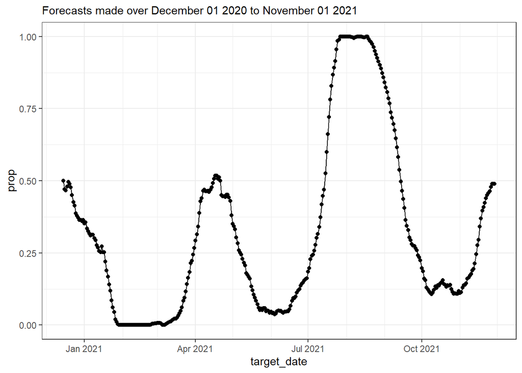

```r
# Plot the proportion of increases over time.

df <- left_join(
  expand_grid(target_date = unique(evals$target_date),
                  actual = "up"),

  evals %>%
    select(geo_value,target_date,actual) %>%
    group_by(target_date, actual) %>%
    summarize(count = n()) %>%
    summarize(prop = count / sum(count), actual = actual) %>%
    filter(actual == "up")
)

ggplot(df %>% replace_na(list(prop = 0)), aes(x = target_date, y = prop)) +
  geom_line() +
  geom_point() +
  scale_x_date(date_minor_breaks = "1 month") +
  labs(subtitle = subtitle)
```

# Evaluation

First up, ROC curves by ahead, aggregated over all days.

## ROC curves

### Direction = up

#### 14 days ahead

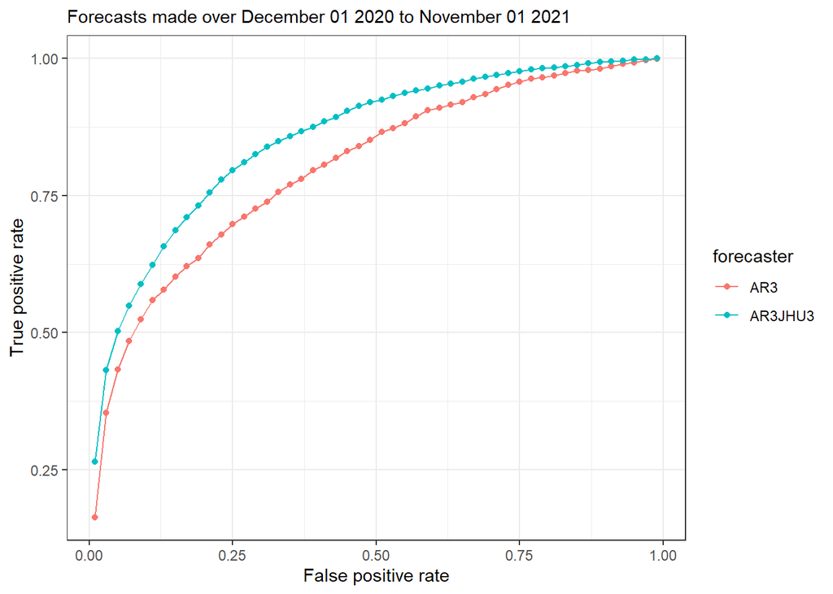

```r
ggplot(all_day_roc[["up"]] %>% filter(ahead == 14),
       aes(x = alpha, y = result, color = forecaster)) +
  geom_point() +
  geom_line() +
  labs(subtitle = subtitle,
       x = "False positive rate",
       y = "True positive rate")
```

#### 21 days ahead

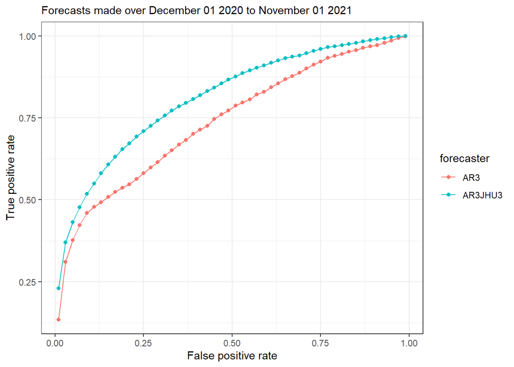

```r
ggplot(all_day_roc[["up"]] %>% filter(ahead == 21),
       aes(x = alpha, y = result, color = forecaster)) +
  geom_point() +
  geom_line() +
  labs(subtitle = subtitle,
       x = "False positive rate",
       y = "True positive rate")
```

#### 28 days ahead

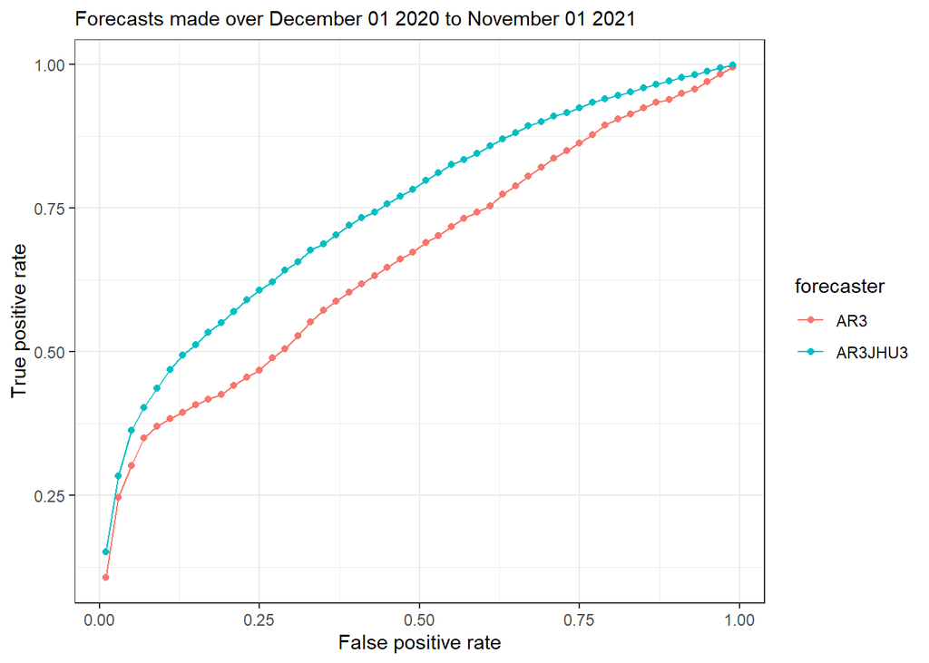

```r
ggplot(all_day_roc[["up"]] %>% filter(ahead == 28),
       aes(x = alpha, y = result, color = forecaster)) +
  geom_point() +
  geom_line() +
  labs(subtitle = subtitle,
       x = "False positive rate",
       y = "True positive rate")
```

### Direction = steady

#### 14 days ahead

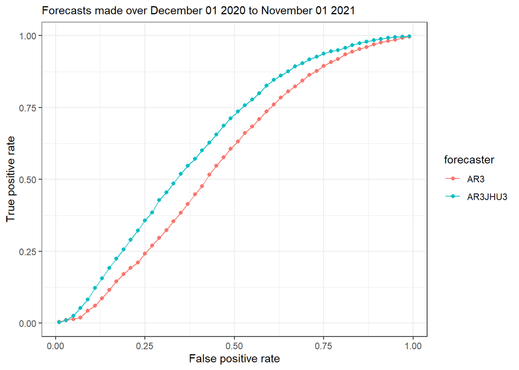

```r
ggplot(all_day_roc[["steady"]] %>% filter(ahead == 14),
       aes(x = alpha, y = result, color = forecaster)) +
  geom_point() +
  geom_line() +
  labs(subtitle = subtitle,
       x = "False positive rate",
       y = "True positive rate")
```

#### 21 days ahead

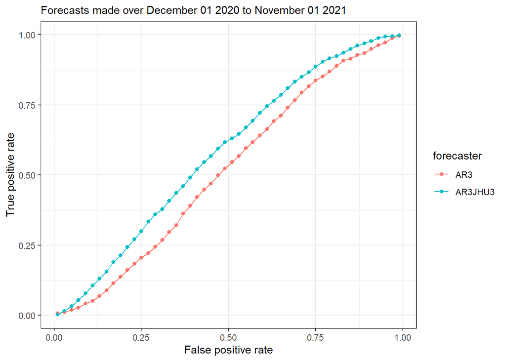

```r
ggplot(all_day_roc[["steady"]] %>% filter(ahead == 21),
       aes(x = alpha, y = result, color = forecaster)) +
  geom_point() +
  geom_line() +
  labs(subtitle = subtitle,
       x = "False positive rate",
       y = "True positive rate")
```

#### 28 days ahead

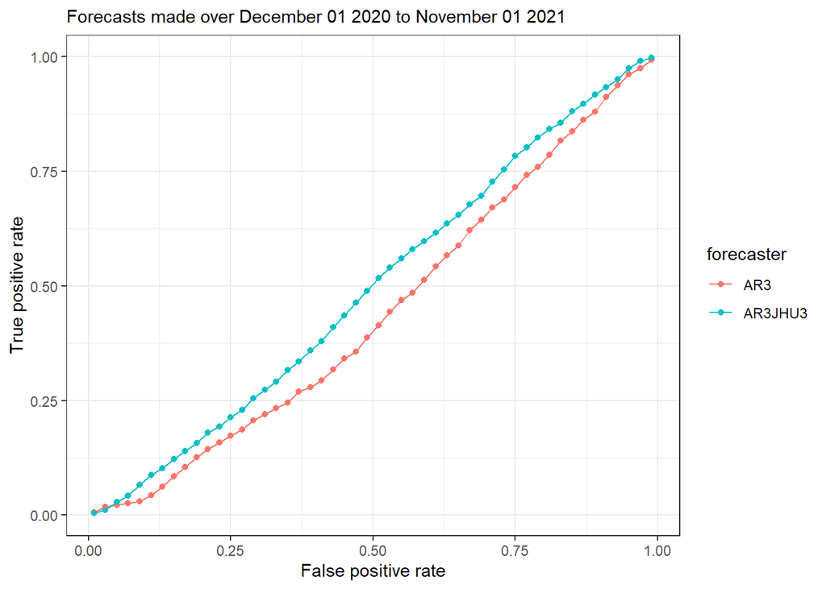

```r
ggplot(all_day_roc[["steady"]] %>% filter(ahead == 28),
       aes(x = alpha, y = result, color = forecaster)) +
  geom_point() +
  geom_line() +
  labs(subtitle = subtitle,
       x = "False positive rate",
       y = "True positive rate")
```

### Direction = down

#### 14 days ahead

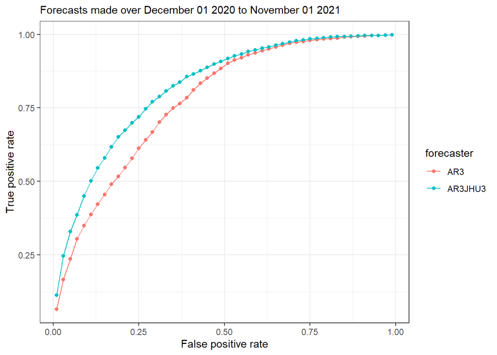

```r
ggplot(all_day_roc[["down"]] %>% filter(ahead == 14),
       aes(x = alpha, y = result, color = forecaster)) +
  geom_point() +
  geom_line() +
  labs(subtitle = subtitle,
       x = "False positive rate",
       y = "True positive rate")
```

#### 21 days ahead

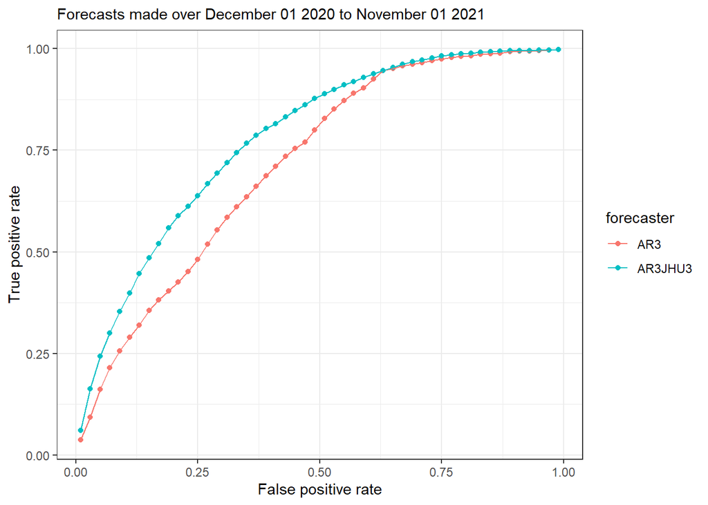

```r
ggplot(all_day_roc[["down"]] %>% filter(ahead == 21),
       aes(x = alpha, y = result, color = forecaster)) +
  geom_point() +
  geom_line() +
  labs(subtitle = subtitle,
       x = "False positive rate",
       y = "True positive rate")
```

#### 28 days ahead

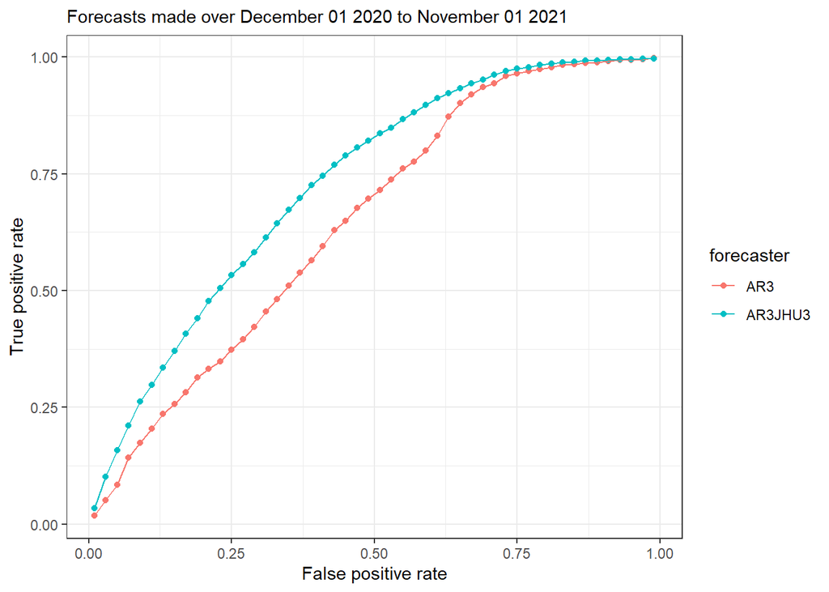

```r
ggplot(all_day_roc[["down"]] %>% filter(ahead == 28),
       aes(x = alpha, y = result, color = forecaster)) +
  geom_point() +
  geom_line() +
  labs(subtitle = subtitle,
       x = "False positive rate",
       y = "True positive rate")
```

Next up, AUC by ahead, aggregated over all dates. The tabs differ in the notion of aggregation:

- In the first tab, we aggregate by taking AUC over all forecast dates.
- In the second tab, we group by forecast year and month, then take AUC over all forecast dates.

## AUC curves by ahead

### All time

#### Direction = up

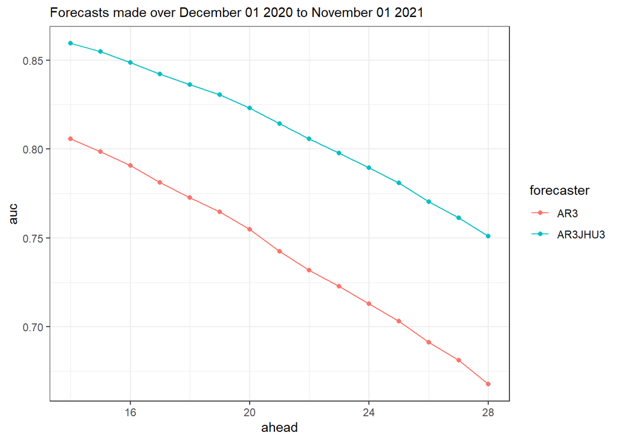

```r
ggplot(all_day_auc[["up"]], aes(x = ahead, y = auc, color = forecaster)) +
  geom_point() +
  geom_line() +
  labs(subtitle = subtitle)
```

#### Direction = steady

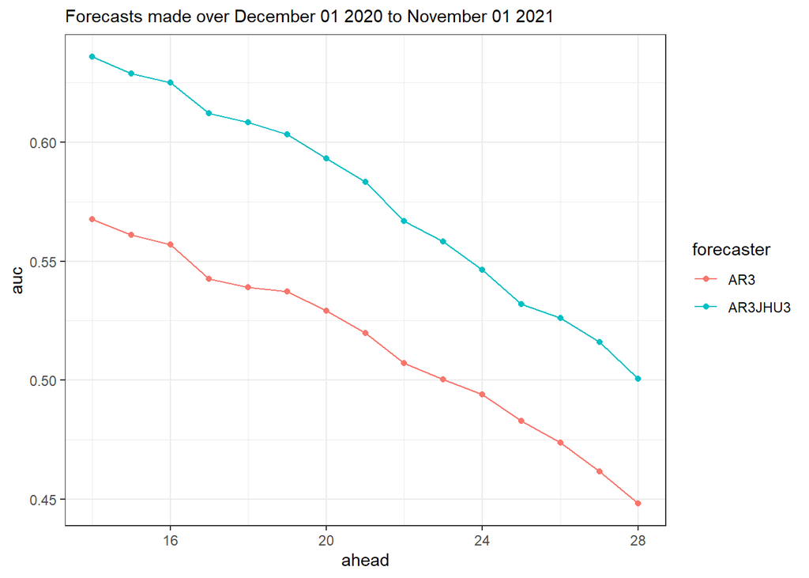

```r
ggplot(all_day_auc[["steady"]], aes(x = ahead, y = auc, color = forecaster)) +
  geom_point() +
  geom_line() +
  labs(subtitle = subtitle)
```

#### Direction = down

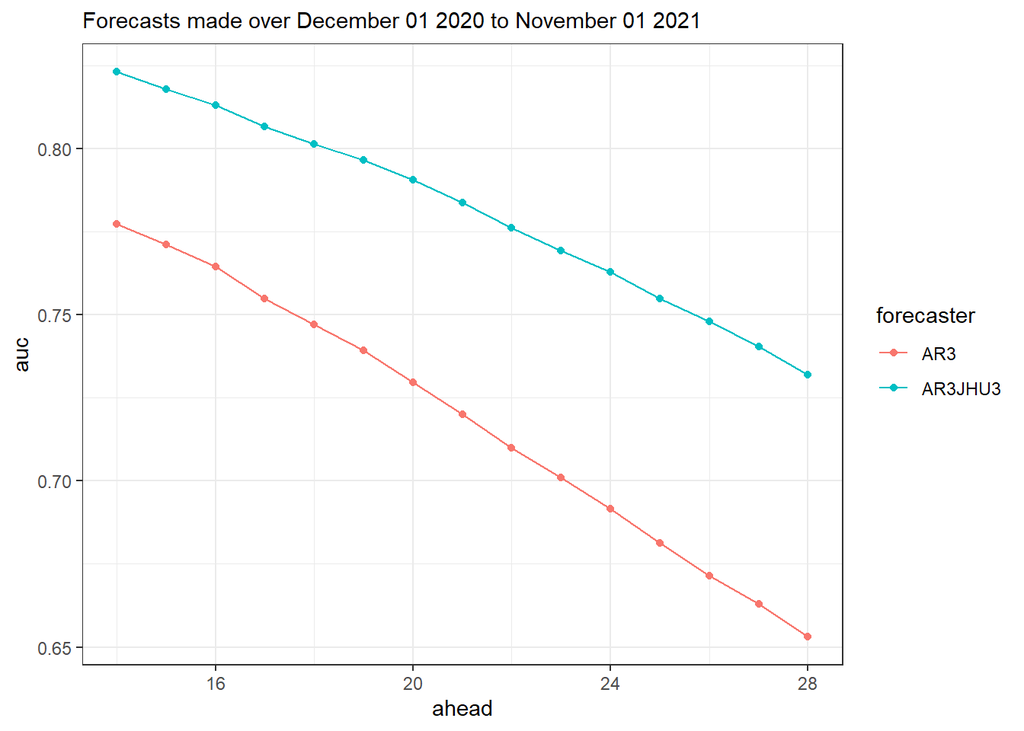

```r
ggplot(all_day_auc[["down"]], aes(x = ahead, y = auc, color = forecaster)) +
  geom_point() +
  geom_line() +
  labs(subtitle = subtitle)
```

### Per Month

#### Direction = up

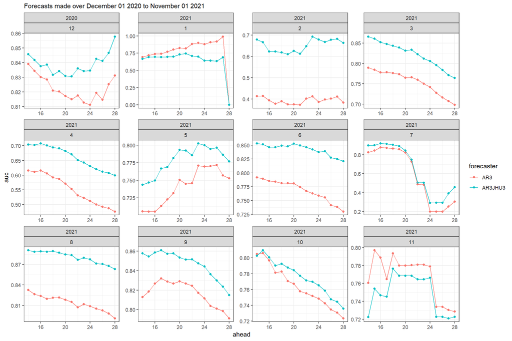

```r
ggplot(per_yearmonth_auc[["up"]], aes(x = ahead, y = auc, color = forecaster)) +
  geom_point() +
  geom_line() +
  labs(subtitle = subtitle) +
  facet_wrap(vars(forecast_year,forecast_month), scales = "free")
```

#### Direction = steady

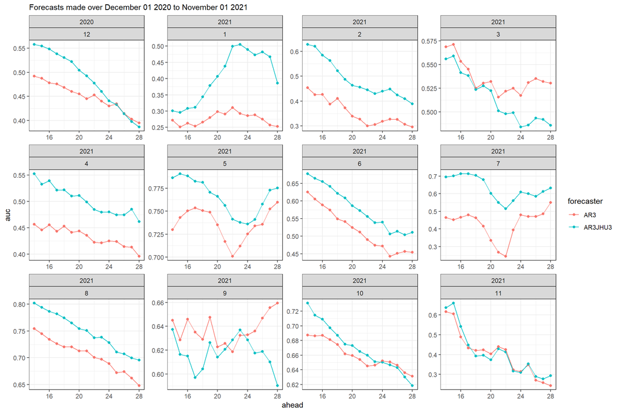

```r
ggplot(per_yearmonth_auc[["steady"]], aes(x = ahead, y = auc, color = forecaster)) +
  geom_point() +
  geom_line() +
  labs(subtitle = subtitle) +
  facet_wrap(vars(forecast_year,forecast_month), scales = "free")
```

#### Direction = down

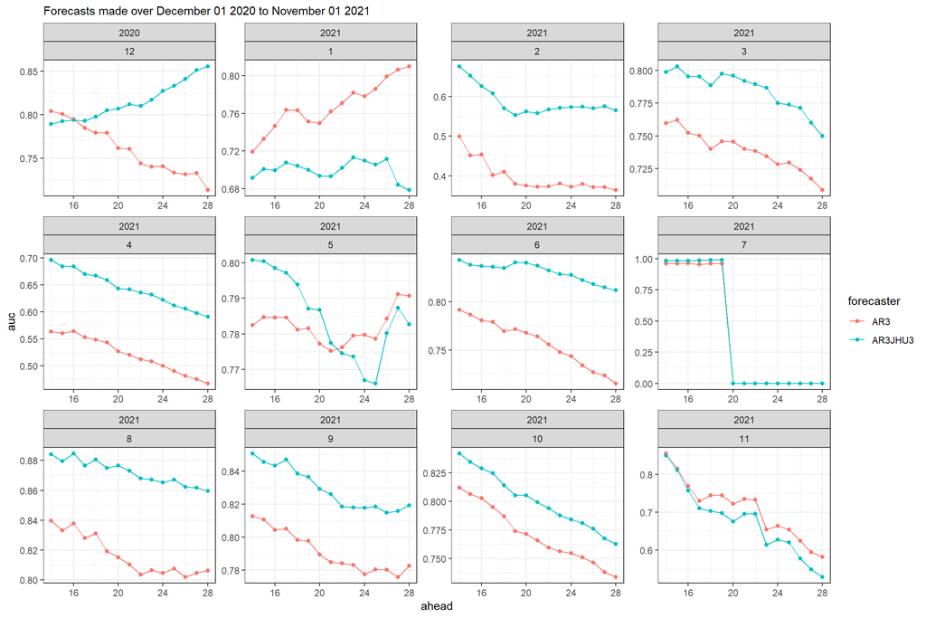

```r
ggplot(per_yearmonth_auc[["down"]], aes(x = ahead, y = auc, color = forecaster)) +
  geom_point() +
  geom_line() +
  labs(subtitle = subtitle) +
  facet_wrap(vars(forecast_year,forecast_month), scales = "free")
```

Finally, difference in fitted values between forecasters, depending on the truth.

## Fitted values

### All aheads

#### Predictions for class = “up”

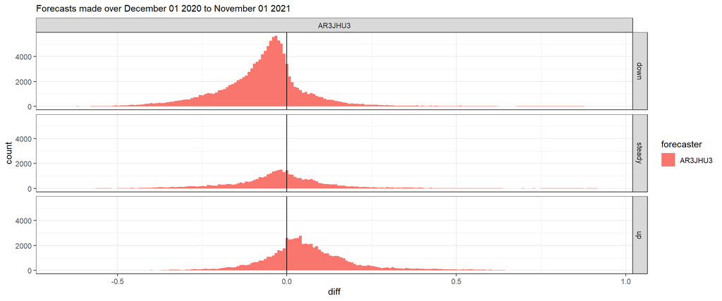

```r
ggplot(diff_evals %>% filter(direction == "up"), aes(x = diff, fill = forecaster)) +
  geom_histogram(bins = 200) +
  labs(subtitle = subtitle) +
  facet_grid(rows = vars(actual),
             cols = vars(forecaster),
             scales = "fixed") +
  geom_vline(xintercept = 0)
```

#### Predictions for class = “steady”

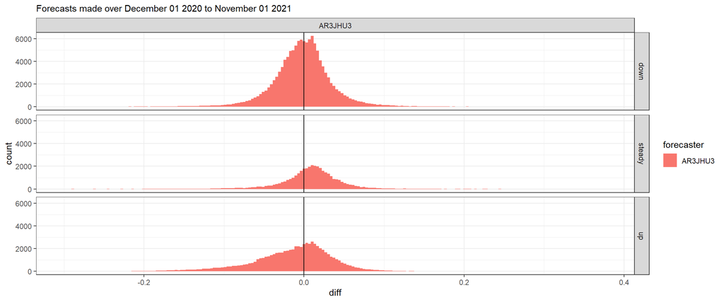

```r
ggplot(diff_evals %>% filter(direction == "steady"), aes(x = diff, fill = forecaster)) +
  geom_histogram(bins = 200) +
  labs(subtitle = subtitle) +
  facet_grid(rows = vars(actual),
             cols = vars(forecaster),
             scales = "fixed") +
  geom_vline(xintercept = 0)
```

#### Predictions for class = “down”

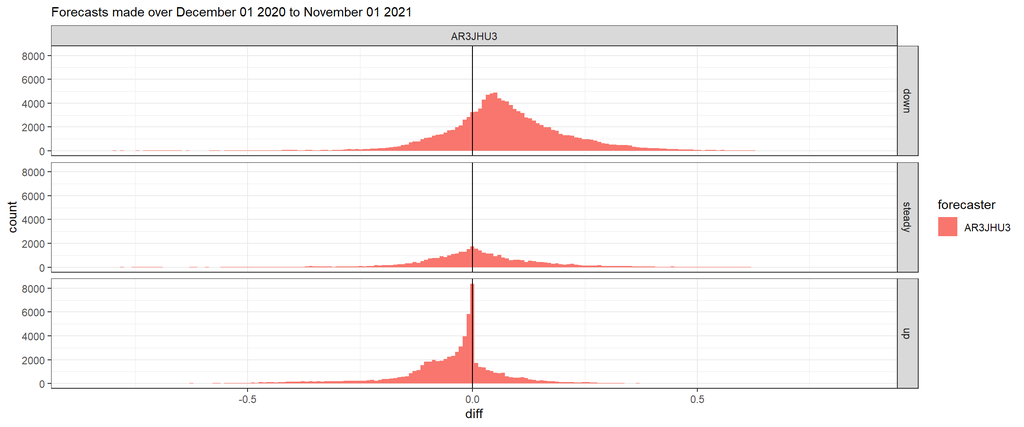

```r
ggplot(diff_evals %>% filter(direction == "down"), aes(x = diff, fill = forecaster)) +
  geom_histogram(bins = 200) +
  labs(subtitle = subtitle) +
  facet_grid(rows = vars(actual),
             cols = vars(forecaster),
             scales = "fixed") +
  geom_vline(xintercept = 0)
```

### By ahead

#### 14 days ahead

##### Predictions for class = “up”

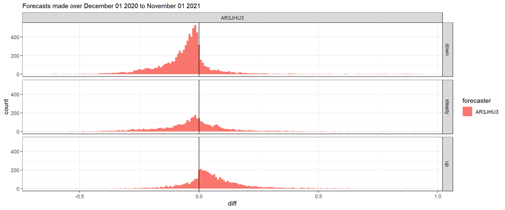

```r
ggplot(diff_evals %>% filter(ahead == 14, direction == "up"), aes(x = diff, fill = forecaster)) +
  geom_histogram(bins = 200) +
  labs(subtitle = subtitle) +
  facet_grid(rows = vars(actual),
             cols = vars(forecaster),
             scales = "fixed") +
  geom_vline(xintercept = 0)
```

##### Predictions for class = “steady”

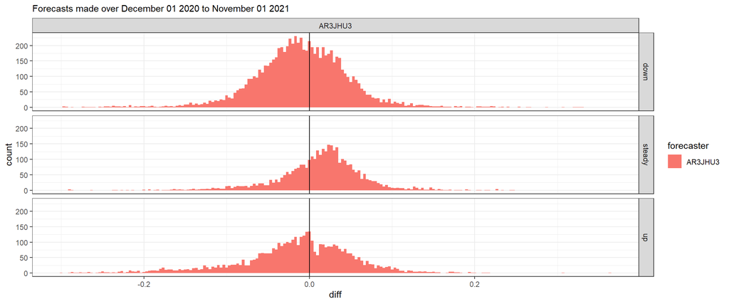

```r
ggplot(diff_evals %>% filter(ahead == 14, direction == "steady"), aes(x = diff, fill = forecaster)) +
  geom_histogram(bins = 200) +
  labs(subtitle = subtitle) +
  facet_grid(rows = vars(actual),
             cols = vars(forecaster),
             scales = "fixed") +
  geom_vline(xintercept = 0)
```

##### Predictions for class = “down”

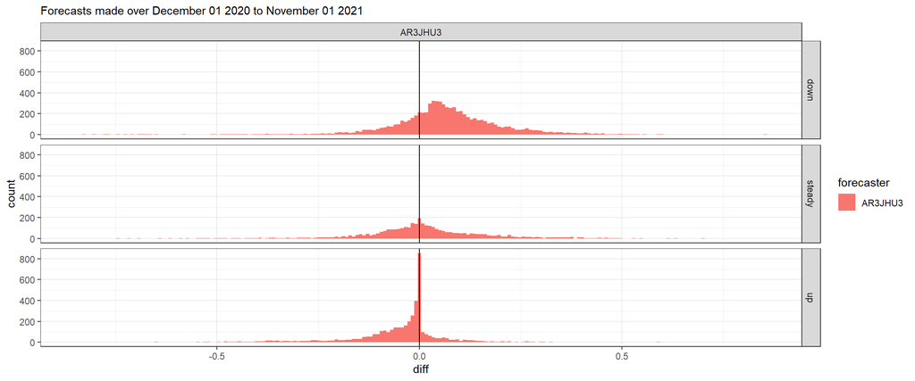

```r
ggplot(diff_evals %>% filter(ahead == 14, direction == "down"), aes(x = diff, fill = forecaster)) +
  geom_histogram(bins = 200) +
  labs(subtitle = subtitle) +
  facet_grid(rows = vars(actual),
             cols = vars(forecaster),
             scales = "fixed") +
  geom_vline(xintercept = 0)
```

#### 21 days ahead

##### Predictions for class = “up”

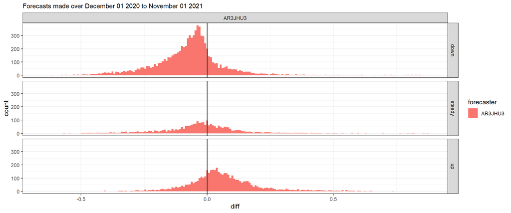

```r
ggplot(diff_evals %>% filter(ahead == 21, direction == "up"), aes(x = diff, fill = forecaster)) +
  geom_histogram(bins = 200) +
  labs(subtitle = subtitle) +
  facet_grid(rows = vars(actual),
             cols = vars(forecaster),
             scales = "fixed") +
  geom_vline(xintercept = 0)
```

##### Predictions for class = “steady”

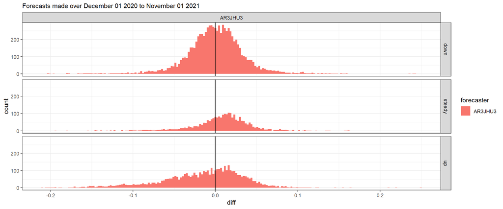

```r
ggplot(diff_evals %>% filter(ahead == 21, direction == "steady"), aes(x = diff, fill = forecaster)) +
  geom_histogram(bins = 200) +
  labs(subtitle = subtitle) +
  facet_grid(rows = vars(actual),
             cols = vars(forecaster),
             scales = "fixed") +
  geom_vline(xintercept = 0)
```

##### Predictions for class = “down”

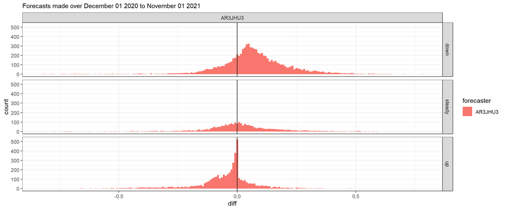

```r
ggplot(diff_evals %>% filter(ahead == 21, direction == "down"), aes(x = diff, fill = forecaster)) +
  geom_histogram(bins = 200) +
  labs(subtitle = subtitle) +
  facet_grid(rows = vars(actual),
             cols = vars(forecaster),
             scales = "fixed") +
  geom_vline(xintercept = 0)
```

#### 28 days ahead

##### Predictions for class = “up”

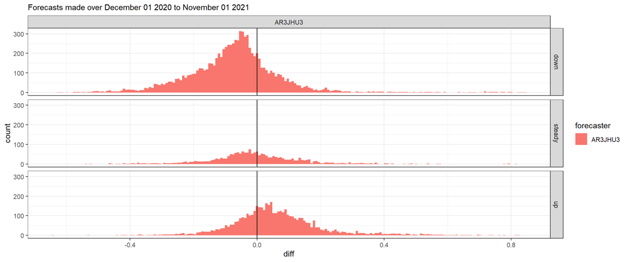

```r
ggplot(diff_evals %>% filter(ahead == 28, direction == "up"), aes(x = diff, fill = forecaster)) +
  geom_histogram(bins = 200) +
  labs(subtitle = subtitle) +
  facet_grid(rows = vars(actual),
             cols = vars(forecaster),
             scales = "fixed") +
  geom_vline(xintercept = 0)
```

##### Predictions for class = “steady”

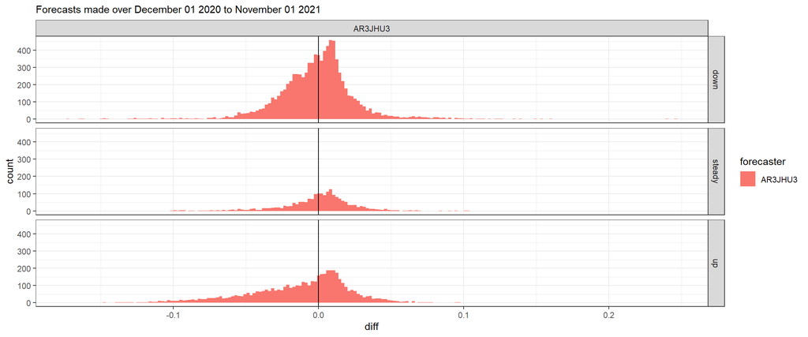

```r
ggplot(diff_evals %>% filter(ahead == 28, direction == "steady"), aes(x = diff, fill = forecaster)) +
  geom_histogram(bins = 200) +
  labs(subtitle = subtitle) +
  facet_grid(rows = vars(actual),
             cols = vars(forecaster),
             scales = "fixed") +
  geom_vline(xintercept = 0)
```

##### Predictions for class = “down”

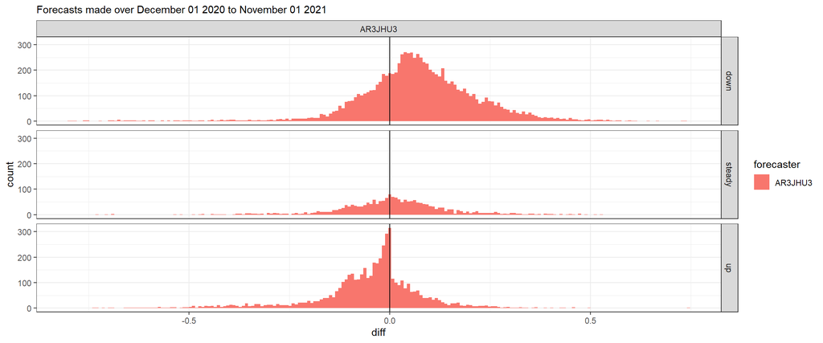

```r
ggplot(diff_evals %>% filter(ahead == 28, direction == "down"), aes(x = diff, fill = forecaster)) +
  geom_histogram(bins = 200) +
  labs(subtitle = subtitle) +
  facet_grid(rows = vars(actual),
             cols = vars(forecaster),
             scales = "fixed") +
  geom_vline(xintercept = 0)
```

```r
knitr::knit_exit()
```